# Comparing the Effectiveness of Treatment for Post-Traumatic Stress Disorder (PTSD) in Veterans and Non-Veterans

Promotion Research of Kirsten Reij

Ernst-Paul Swens, [Swens Data Science](https://ernst-paul.github.io/)

February 16, 2023

# 1. Data Preperation

We examined the data prior to conducting any statistical analysis. We started by reformatting and re-coding variables, followed by a matching procedure. Lastly, we present the descriptive statistics of the matched dataset.

## 1.1. Data Inspection

The following `R` packages were utilized.

```r
library(lubridate)   # package to help calculate age of patients
library(tableone)    # package to help create descriptive table
library(magrittr)    # package to add additional pipe options
library(labelled)    # package to help with labeling columns
library(MatchIt)     # package for the matching procedure
library(ggplot2)     # package for creating fancy plots
library(ggpubr)      # package to combine fancy plots
library(table1)      # package to create table one
library(tidyr)       # package to make life easier
library(dplyr)       # package to make life easier
```

We performed feature reduction on the raw data, retaining only the variables `veteran`, `starting_date`, `age`, `sex`, `pre_score`, `post_score`, `pre_diagnosis`, `post_diagnosis` and `duration`. We re-coded the variables `veteran`, `starting_date`, and `age`. We created a missingness indicator `follow_up_miss` for the follow-up treatment score. There was one veteran removed without the pre-treatment diagnosis of PTSD.

| **Variable** | **Explanation** | **Coding** |
| --- | --- | --- |
| `veteran` | being a veteran | factor |
| `starting_date` | date start treatment | date |
| `sex` | sex of patient | factor |
| `age` | age of patient | continuous |
| `pre_score` | pre-treatment CAPS score | continuous |
| `post_score` | post-treatment CAPS score | continuous |
| `follow_up_miss` | missingness indicator for follow-up score | factor |
| `pre_diagnosis` | diagnosis of PTSD pre-treatment | factor |
| `post_diagnosis` | diagnosis of PTSD post-treatment | factor |
| `duration` | treatment duration | factor |

```r
# set seed to make results reproducible
set.seed(123)

# read in data
data <- read.csv("data/data_raw.csv")

# include a unique id
data <- data %>% dplyr::mutate(id = row_number())

# select relevant columns, clean dates, list-wise omit missing data
vet <- data %>%
  dplyr::select(IsVeteraan, id) %>%
  dplyr::mutate(
    veteran           = as.factor(IsVeteraan),
    sex               = data$geslacht,
    starting_date     = as.Date(data$StartDatum, "%Y-%m-%d"),
    age               = trunc((as.Date(data$geboortedatum, "%Y-%m-%d")
                          %--% Sys.Date()) / years(1)),
    pre_score         = data$CAPS5Score_IN,
    post_score        = data$CAPS5Score_TK,
    follow_up_miss    = !is.na(data$CAPS5Score_FU),
    pre_diagnosis     = factor(
      data$diagnose_IN,
      levels = c(0, 1),
      labels = c("No PTSD", "PTSD")),
    post_diagnosis    = factor(
      data$diagnose_TK,
      levels = c(0, 1),
      labels = c("No PTSD", "PTSD")),
    duration          = factor(
      data$BEHDAGEN_GEPLAND > 7,
      levels = c(TRUE, FALSE),
      labels = c("8 days or more", "Less than 8 days"))) %>%
  dplyr::select(-IsVeteraan) %>%
  dplyr::filter(id != 47) %>%
  dplyr::filter(pre_diagnosis == "PTSD") %>%
  na.omit()
```

## 1.2. Matching

Before making statistical inferences, we took into account the class imbalance of `veteran` and the potential confounding effects of `age`, `sex`, and `duration`.

```
##                                  Stratified by veteran
##                                   0             1             p      test
##   n                                3848            43
##   sex (mean (SD))                  1.63 (0.48)   1.07 (0.26)  <0.001
##   age (mean (SD))                 41.71 (12.49) 46.93 (8.29)   0.006
##   duration = Less than 8 days (%)  1035 (26.9)      9 (20.9)   0.481
##                                  Stratified by veteran
##                                   SMD
##   n
##   sex (mean (SD))                  1.438
##   age (mean (SD))                  0.493
##   duration = Less than 8 days (%)  0.140
```

```r
# matching non-veterans
match <- matchit(
   veteran ~ sex + age + starting_date + duration,
   method = "nearest",
   data = vet)

# matched data frame
vet <- rbind(vet[match[["match.matrix"]],], dplyr::filter(vet, veteran == 1))
```

After the matching procedure, we observed a significant decrease in the standardized mean difference. This suggests that the matching procedure was successful in controlling the confounding effects of `age`, `sex`, and `duration`.

```
##                                  Stratified by veteran
##                                   0             1             p      test
##   n                                  43            43
##   sex (mean (SD))                  1.07 (0.26)   1.07 (0.26)   1.000
##   age (mean (SD))                 46.07 (9.76)  46.93 (8.29)   0.661
##   duration = Less than 8 days (%)     8 (18.6)      9 (20.9)   1.000
##                                  Stratified by veteran
##                                   SMD
##   n
##   sex (mean (SD))                 <0.001
##   age (mean (SD))                  0.095
##   duration = Less than 8 days (%)  0.058
```

## 1.3. Patient Characteristics

The following table presents the patient characteristics.

|  | Total (N=86) | Non-Veteran (N=43) | Veteran (N=43) | p-value |
| --- | --- | --- | --- | --- |
| Sex |  |  |  |  |
| Male | 80 (93.0%) | 40 (93.0%) | 40 (93.0%) | 1 |
| Female | 6 (7.0%) | 3 (7.0%) | 3 (7.0%) |  |
| Pre-treatment CAPS score |  |  |  |  |
| Mean (SD) | 43.6 (7.21) | 43.3 (7.16) | 43.9 (7.33) | 0.667 |
| Median [Min, Max] | 44.0 [24.0, 61.0] | 44.0 [24.0, 57.0] | 45.0 [25.0, 61.0] |  |
| Post-treatment CAPS score |  |  |  |  |
| Mean (SD) | 14.6 (15.4) | 15.7 (17.0) | 13.5 (13.7) | 0.51 |
| Median [Min, Max] | 8.00 [0, 68.0] | 8.00 [0, 68.0] | 8.00 [0, 48.0] |  |
| Difference post and pre-score |  |  |  |  |
| Mean (SD) | -29.0 (15.6) | -27.5 (17.1) | -30.4 (14.0) | 0.395 |
| Median [Min, Max] | -31.0 [-53.0, 18.0] | -31.0 [-53.0, 18.0] | -31.0 [-51.0, 2.00] |  |
| Age |  |  |  |  |
| Mean (SD) | 46.5 (9.01) | 46.1 (9.76) | 46.9 (8.29) | 0.661 |
| Median [Min, Max] | 46.0 [30.0, 67.0] | 44.0 [30.0, 67.0] | 46.0 [33.0, 67.0] |  |
| War violence |  |  |  |  |
| No | 39 (45.3%) | 38 (88.4%) | 1 (2.3%) | <0.001 |
| Yes | 47 (54.7%) | 5 (11.6%) | 42 (97.7%) |  |
| Sexual violence |  |  |  |  |
| No | 40 (46.5%) | 12 (27.9%) | 28 (65.1%) | 0.0015 |
| Yes | 46 (53.5%) | 31 (72.1%) | 15 (34.9%) |  |
| Physical violence |  |  |  |  |
| No | 12 (14.0%) | 4 (9.3%) | 8 (18.6%) | 0.362 |
| Yes | 74 (86.0%) | 39 (90.7%) | 35 (81.4%) |  |
| Natural disasters and serious accidents |  |  |  |  |
| No | 11 (12.8%) | 8 (18.6%) | 3 (7.0%) | 0.198 |
| Yes | 75 (87.2%) | 35 (81.4%) | 40 (93.0%) |  |
| Mood disorders |  |  |  |  |
| No | 39 (45.3%) | 21 (48.8%) | 18 (41.9%) | 0.661 |
| Yes | 47 (54.7%) | 22 (51.2%) | 25 (58.1%) |  |
| Anxiety disorders |  |  |  |  |
| No | 48 (55.8%) | 23 (53.5%) | 25 (58.1%) | 0.841 |
| Yes | 38 (44.2%) | 20 (46.5%) | 18 (41.9%) |  |
| Suicide risk |  |  |  |  |
| None | 30 (34.9%) | 15 (34.9%) | 15 (34.9%) | 0.244 |
| Low | 32 (37.2%) | 15 (34.9%) | 17 (39.5%) |  |
| Medium | 12 (14.0%) | 4 (9.3%) | 8 (18.6%) |  |
| High | 9 (10.5%) | 7 (16.3%) | 2 (4.7%) |  |
| Missing | 3 (3.5%) | 2 (4.7%) | 1 (2.3%) |  |
| Treatment duration |  |  |  |  |
| 8 days or more | 69 (80.2%) | 35 (81.4%) | 34 (79.1%) | 1 |
| Less than 8 days | 17 (19.8%) | 8 (18.6%) | 9 (20.9%) |  |

> **About Including p-values in Table 1**

> Including p-values in Table 1 may be easy, but it is not recommended. This is true whether the data is from an observational study or a randomized trial. If p-values are included to show crude associations between predictors and outcomes, they may not be relevant as adjusted assessments from regression analysis are usually more important. Including p-values in Table 1 to show differences in participant characteristics between exposure groups is not useful. What matters for confounding is the magnitude of differences in the sample, not if the groups differ in the population (as tested by p-values).

# 2. Missing Data in Follow-Up

## 2.1. Missing Data Mechanisms

First, we will explain some technical terms. Then, we will give a more understandable explanation.

The variable $R$ represents whether or not a follow-up CAPS score is missing, where $R = 0$ represents a missing score and $R = 1$ represents a known score. The distribution of $R$ may depend on the data, represented by $Y$. This data may contain complete and missing information, represented by $Y = (Y_{obs}, Y_{mis})$. The missing data may be due to either design or circumstance, such as a forgotten confounding variable. The parameter of the missing data model is represented by $\psi$, and the general expression of the missing data model is $P(R=0|Y_{obs}, Y_{mis},\psi)$, which expresses the probability that the follow-up score is missing, given the observed and missing data, and the parameter of the missing data model.

We can now formulate the hypothesis that:

$$H_0: P(R=0|Y_{obs},
Y_{mis},\psi)=P(R=0|\psi).$$
This implies that the observations with missing follow-up scores are a random subset of all observations, determined by $\psi$. Therefore, there are no systematic differences between the missing and observed follow-up scores. This is known as missing completely at random (MCAR).

The alternative hypothesis is formulated as:

$$H_1: P(R=0|Y_{obs}, Y_{mis},\psi) \ne
P(R=0|\psi)$$
This means that the observations with missing follow-up scores are not a random subset of all observations. The missingness may depend on another observed variable, such as veterans with higher pre-treatment scores being less likely to be lost to follow-up. This is known as a missing at random (MAR) mechanism. If the missingness depends on something that was not measured, it is called missing not at random (MNAR).

It is not possible to definitively distinguish between MCAR, MAR, and MNAR based on the data alone. However, by analyzing the standardized mean differences between the two groups, we can infer which mechanism is most likely to be the cause of missing data. If the standardized mean differences are small, it suggests that the missing data is likely MCAR. If the standardized mean differences are larger, it suggests that the missing data may be MAR or MNAR.

## 2.2. Exploration

```
##                                  Stratified by follow_up_miss
##                                   FALSE          TRUE           p      test
##   n                                   20             23
##   age (mean (SD))                  44.95 (7.86)   48.65 (8.45)   0.146
##   duration = Less than 8 days (%)      4 (20.0)       5 (21.7)   1.000
##   pre_score (mean (SD))            42.55 (8.68)   45.13 (5.84)   0.254
##   diff_score (mean (SD))          -30.50 (13.08) -30.30 (15.04)  0.964
##                                  Stratified by follow_up_miss
##                                   SMD
##   n
##   age (mean (SD))                  0.454
##   duration = Less than 8 days (%)  0.043
##   pre_score (mean (SD))            0.349
##   diff_score (mean (SD))           0.014
```

There are minimal variations between the groups as indicated by the SMD being less than 0.5. This is also supported by the figure which shows that the distributions of the groups overlap nicely.

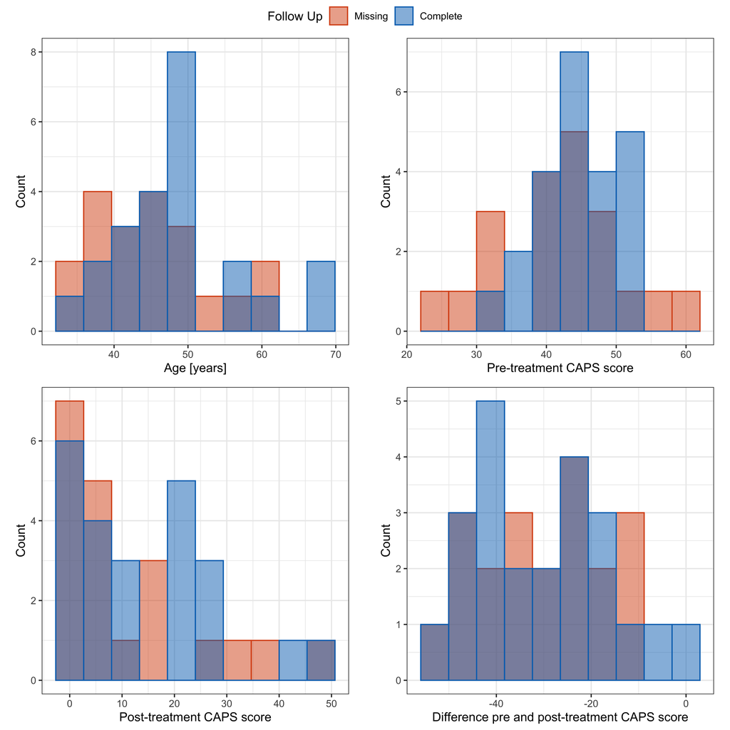

In conclusion, the reason for the missing follow-up score appears to be random, supporting the assumption that $H_0$ is true.

# 3. Marginal Analysis

In this chapter, we investigate the effectiveness of the treatment for both veterans and non-veterans by examining the pre- and post-treatment scores. The figure presents the CAPS scores for both groups, which show a decrease in the CAPS scores. Note, the error bars in the figure below shows the 95% confidence interval of the paired t-test. The following sections will determine if this decrease is statistically significant and clinically meaningful.

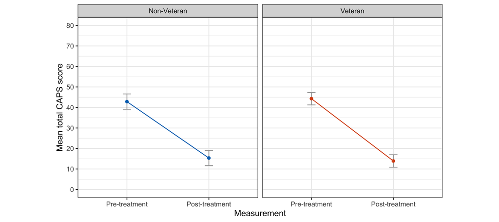

## 3.1. Veterans

For the veteran group, the following hypotheses can be formulated:

- Null Hypothesis ($H_0$): The treatment has no effect on the CAPS score. This is represented by the difference between the pre-treatment and post-treatment scores being greater than or equal to zero ($CAPS_{post} - CAPS_{pre} \ge 0$).
- Alternative Hypothesis ($H_1$): The treatment does decrease the CAPS score. This is represented by the difference between the pre-treatment and post-treatment scores being less than zero ($CAPS_{post} - CAPS_{pre} < 0$).

These hypotheses can be tested using a paired t-test. The effect size can be quantified by Cohen’s distance.

```
##
##  Paired t-test
##
## data:  post_score and pre_score
## t = -14.238, df = 42, p-value < 2.2e-16
## alternative hypothesis: true mean difference is less than 0
## 95 percent confidence interval:
##       -Inf -26.80479
## sample estimates:
## mean difference
##       -30.39535
```

The results from the pre-test (M = 43.9, SD = 7.3) and post-test (M = 13.5, SD = 13.7) CAPS interview indicate that the treatment significantly reduced symptoms of PTSD in veterans with war-related trauma, t(42) = -14.2, p < 0.001.

```
##
## Cohen's d
##
## d estimate: 2.763555 (large)
## 95 percent confidence interval:
##   lower   upper
## 2.16395 3.36316
```

The effect size for this analysis (d = 2.76) was found to exceed Cohen’s (1988) convention for a large effect (d = .80).

## 3.2. Non-Veterans

For the non-veteran group, the following hypotheses can be formulated:

- Null Hypothesis ($H_0$): The treatment has no effect on the CAPS score. This is represented by the difference between the pre-treatment and post-treatment scores being greater than or equal to zero ($CAPS_{post} - CAPS_{pre} \ge 0$).
- Alternative Hypothesis ($H_1$): The treatment does decrease the CAPS score. This is represented by the difference between the pre-treatment and post-treatment scores being less than zero ($CAPS_{post} - CAPS_{pre} < 0$).

These hypotheses can be tested using a paired t-test. The effect size can be quantified by Cohen’s distance.

```
##
##  Paired t-test
##
## data:  post_score and pre_score
## t = -10.527, df = 42, p-value = 1.184e-13
## alternative hypothesis: true mean difference is less than 0
## 95 percent confidence interval:
##       -Inf -23.11601
## sample estimates:
## mean difference
##       -27.51163
```

[output not shown]

# 4. RCI

The Reliable Change Index (RCI) is a statistical tool used to determine whether a change in a test score is meaningful or simply due to random measurement error. The RCI takes into account the reliability of the measure, the variability in the obtained scores in the group, and the change in the individual’s score and yields a pseudo–z-statistic. It is important to note that the RCI is only a rough estimate of the meaningfulness of a change and does not guarantee that a change is real or significant.

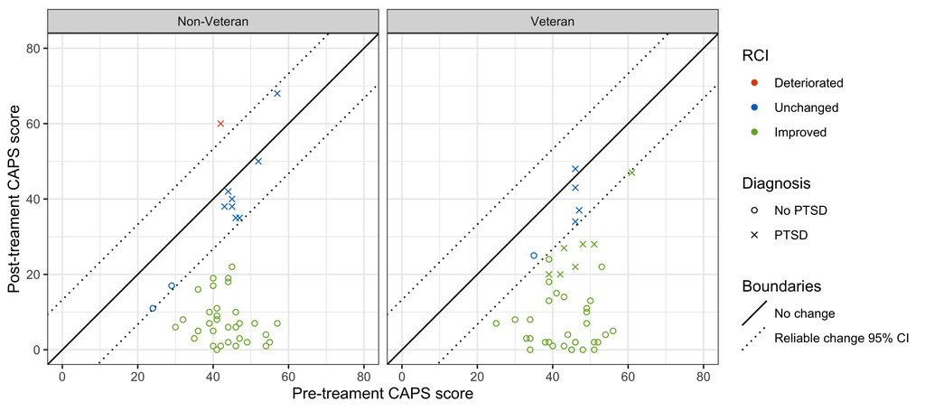

```
##
##               Deteriorated Unchanged Improved
##   Non-Veteran            1        10       32
##   Veteran                0         5       38
```

```
##
##               No PTSD PTSD
##   Non-Veteran      34    9
##   Veteran          32   11
```

# 5. Group Differences

This chapter explores if there exists a difference in treatment response between the veterans and non-veterans.

## 5.1. Analysis

Simply put, the Bayesian ANCOVA quantifies how likely the data comes from one the presented models below.

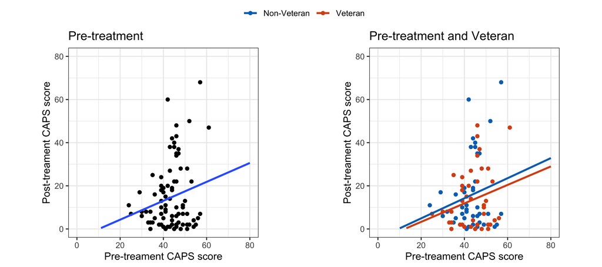

The following tables present the ANCOVA results.

| Model Comparison |  |  |  |  |  |
| --- | --- | --- | --- | --- | --- |
| **Models** | $P(M)$ | $P(M\\|data)$ | $BF_M$ | $BF_{10}$ | error % |
| Null model | 0.500 | 0.775 | 3.445 | 1.000 |  |
| Veteran | 0.500 | 0.225 | 0.290 | 0.290 | 0.967 |

**Note** All models include pre-score

Only the null model had their model odds $P(M\|data)$ increased after observing the data. The null model was most probable, and to the Veteran model using the Bayes Factor $BF_{10}$. The data are 3.45 times more likely under the null model than the veteran model. Or in other words, it is 3.45 times more likely that group membership has no effect on treatment success.

From the model averaged posterior summary, we can observe that the 95% credible interval of both levels of the veteran effect contains the value zero. This also supports that there is no effect of group membership on the effectiveness of treatment.

| Model Averaged Posterior Summary |  |  |  |  |  |
| --- | --- | --- | --- | --- | --- |
| **Variable** | **Level** | **Mean** | **SD** | **95% CI Lower** | **95% CI Upper** |
| Intercept |  | 15.803 | 1.797 | 12.160 | 19.379 |
| Veteran | Non-Veteran | 2.150 | 1.698 | -1.255 | 5.480 |
|  | Veteran | -2.150 | 1.698 | -5.512 | 1.224 |
| Pre Score |  | 0.332 | 0.232 | -0.132 | 0.800 |

## 5.2. Assumptions

For the ANCOVA, there are the following assumptions:

- Linearity
- Homogeneity of regression slopes
- Normality of residuals

Next, we are going to test these assumptions.

There appears to be a linear relationship between pre-test and post-test CAPS score for each group, as assessed by visual inspection of a scatter plot.

```r
# homogeneity of regression slopes
summary(lm(post_score ~ pre_score * veteran, data = vet))
```

```
##
## Call:
## lm(formula = post_score ~ pre_score * veteran, data = vet)
##
## Residuals:
##     Min      1Q  Median      3Q     Max
## -19.745 -12.296  -4.235   7.507  45.858
##
## Coefficients:
##                          Estimate Std. Error t value Pr(>|t|)
## (Intercept)              -4.39082   14.46199  -0.304    0.762
## pre_score                 0.46549    0.32995   1.411    0.162
## veteranVeteran           -0.88723   20.37496  -0.044    0.965
## pre_score:veteranVeteran -0.03724    0.46128  -0.081    0.936
##
## Residual standard error: 15.31 on 82 degrees of freedom
## Multiple R-squared:  0.04876,    Adjusted R-squared:  0.01396
## F-statistic: 1.401 on 3 and 82 DF,  p-value: 0.2484
```

From the non-significance of the interaction term, the homogeneity of regression slopes assumption appears to hold. This is also supported by a visual inspection from the figure above.

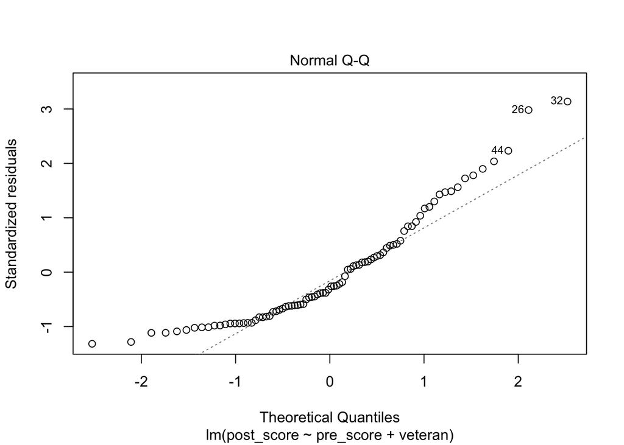

```r
# normality of residuals
model <- lm(post_score ~ pre_score + veteran, data = vet)
plot(model, which = 2)
```

The QQ plot shows that the normality of residuals holds. There is a slight deviation at the tails, but this is often the case in practice.